# Covid-19

A.Doynikov,

3/2/2021

## Пример с COVID-19

Здесь мы построим prophet модель для прогноза ежедневных смертей от COVID-19 в России. Сначала получим данные (Skipped Code)

[output not shown]

```
## # A tibble: 6 x 5
##   date         tests confirmed recovered deaths
##   <date>       <int>     <int>     <int>  <int>
## 1 2020-04-03  639606      4149       281     34
## 2 2020-04-04  697004      4731       333     43
## 3 2020-04-05  758401      5389       355     45
## 4 2020-04-06  795523      6343       406     47
## 5 2020-04-07  910221      7497       494     58
## 6 2020-04-08 1004719      8672       580     63
```

```
## # A tibble: 6 x 5
##   date           tests confirmed recovered deaths
##   <date>         <int>     <int>     <int>  <int>
## 1 2021-03-19        NA   4388268   4003682  92704
## 2 2021-03-20        NA   4397816   4014770  93090
## 3 2021-03-21 117721946   4407031   4023460  93457
## 4 2021-03-22        NA   4416226   4031205  93812
## 5 2021-03-23        NA   4424595   4041716  94231
## 6 2021-03-24        NA   4433364   4051703  94624
```

От накопленных данных перейдем к ежедневным приростам (Skipped Code)

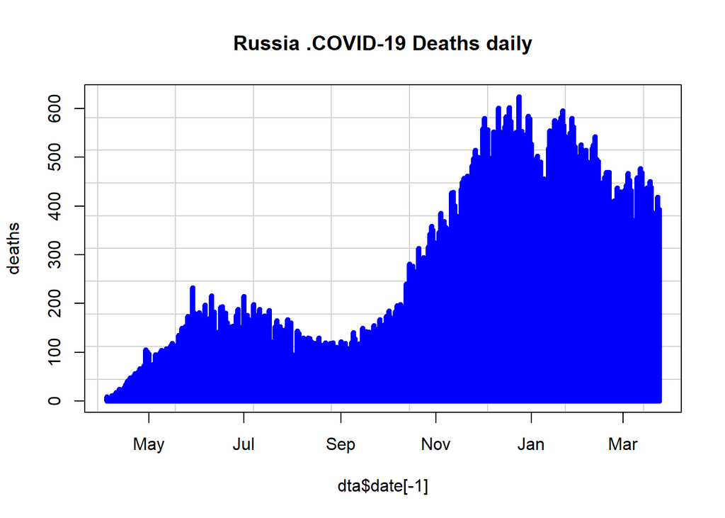

Ежедневный прирост подтвержденных заболеваний будем в последствии использовать в качестве предиктора.

Подготовим `data.frame` для пакета **prophet** (Skipped Code)

```
## [1] 356
```

Сначала оценим prophet модель без предиктора (Skipped Code)

```
## Disabling yearly seasonality. Run prophet with yearly.seasonality=TRUE to override this.
```

```
## Disabling daily seasonality. Run prophet with daily.seasonality=TRUE to override this.
```

```
## $growth
## [1] "linear"
##
## $changepoints
##  [1] "2020-04-15 GMT" "2020-04-27 GMT" "2020-05-08 GMT" "2020-05-19 GMT"
##  [5] "2020-05-31 GMT" "2020-06-11 GMT" "2020-06-22 GMT" "2020-07-04 GMT"
##  [9] "2020-07-15 GMT" "2020-07-26 GMT" "2020-08-07 GMT" "2020-08-18 GMT"
## [13] "2020-08-29 GMT" "2020-09-09 GMT" "2020-09-21 GMT" "2020-10-02 GMT"
## [17] "2020-10-13 GMT" "2020-10-25 GMT" "2020-11-05 GMT" "2020-11-16 GMT"
## [21] "2020-11-28 GMT" "2020-12-09 GMT" "2020-12-20 GMT" "2021-01-01 GMT"
## [25] "2021-01-12 GMT"
##
## $n.changepoints
## [1] 25
##
## $changepoint.range
## [1] 0.8
##
## $yearly.seasonality
## [1] "auto"
##
## $weekly.seasonality
## [1] "auto"
```

Зададим период прогноза 20 дней и построим прогнозы (Skipped Code)

График прогноза

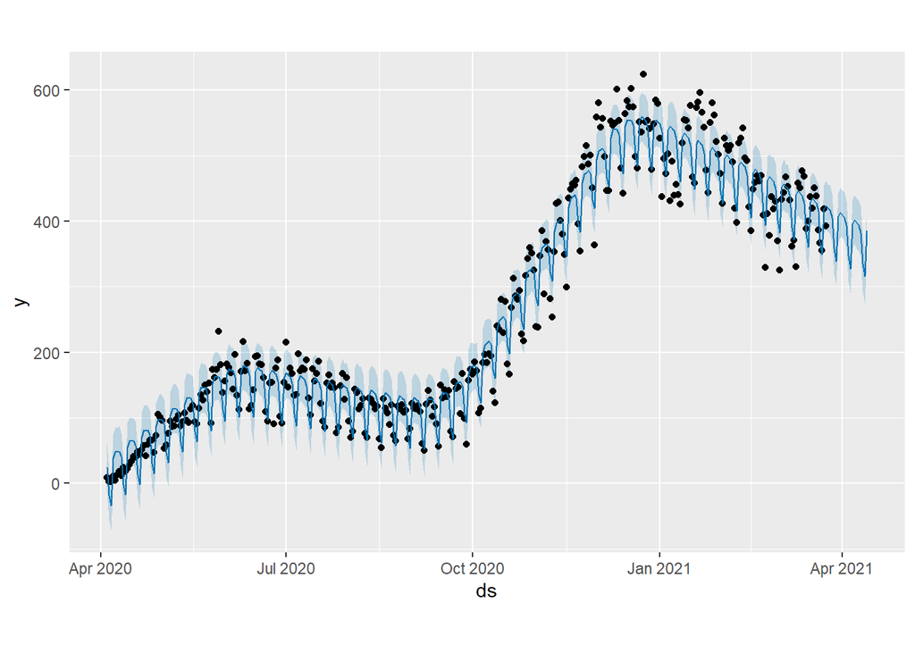

Тренд и недельная сезонная компонента смертности (Skipped Code)

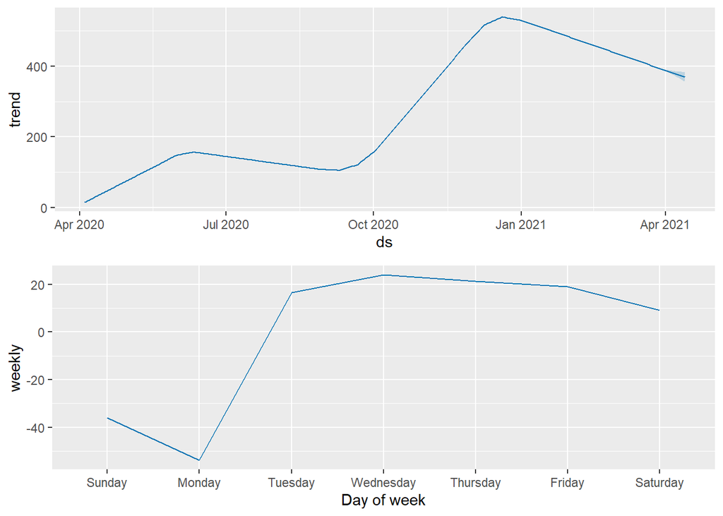

```r
prophet_plot_components(model,forecast)
```

Заметим, что минимальная смертность здесь приходится на воскресенье и понедельник. На самом деле, так как данные выходят за прошлые сутки, то минимум смертности регистрируется в субботу и воскресенье.

Проведем кросс-валидацию прогнозов. Будем вычислять прогнозы на основе исторических точек отсечения. Начиная с конца данных - горизонт `horizon=20`, двигаясь в обратном направлении, делая отсечки с интервалом равным каждые 10 дней, до тех пор, пока не достигнем начала данных. Затем вычислим средний модуль ошибки (mae -mean abs. error) прогноза для каждого из 20 дней горизонта прогноза. (Skipped Code)

```
## Making 28 forecasts with cutoffs between 2020-06-07 and 2021-03-04
```

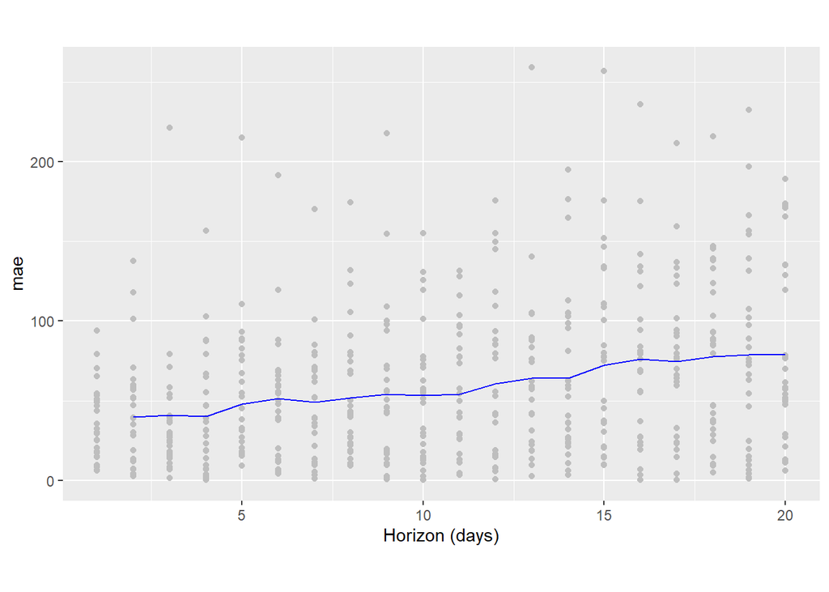

Попробуем уменьшить ошибку прогноза добавлением предиктора - числа ежедневных подтверждений. Предположение о том, что число умерших зависит от числа заболевших весьма оправдано. Но здесь мы не сможем прогнозировать, так как для прогноза вперед нам нужен прогноз числа заболевших. Как преодолеть этот недостаток покажем чуть позже.

(Skipped Code)

```
## Disabling yearly seasonality. Run prophet with yearly.seasonality=TRUE to override this.
```

```
## Disabling daily seasonality. Run prophet with daily.seasonality=TRUE to override this.
```

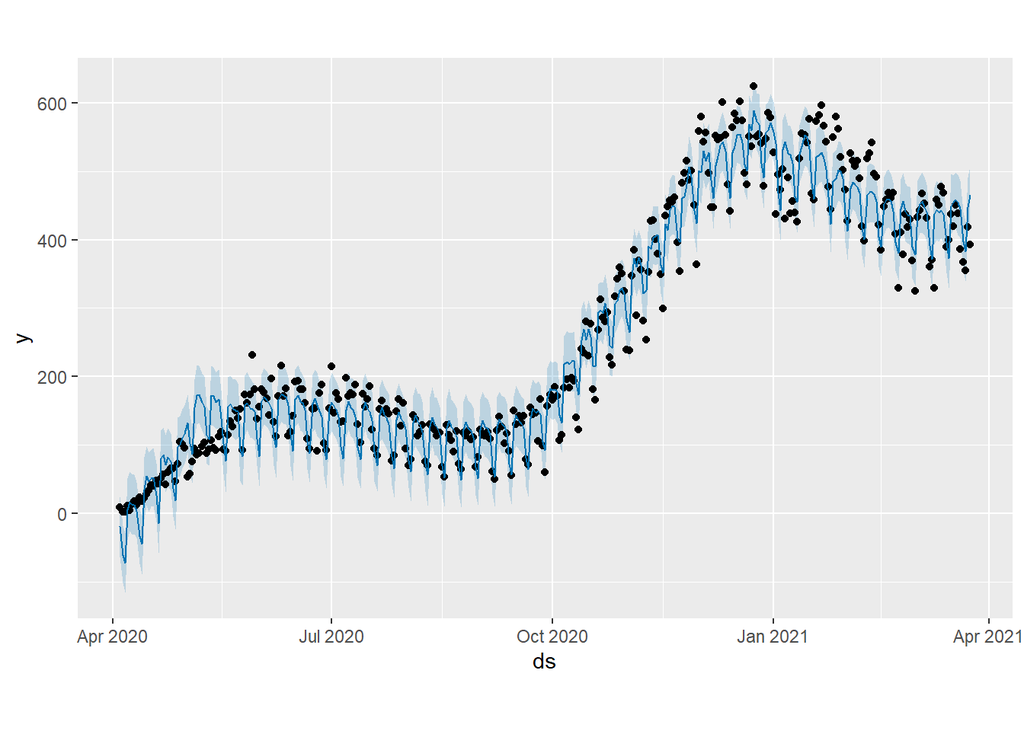

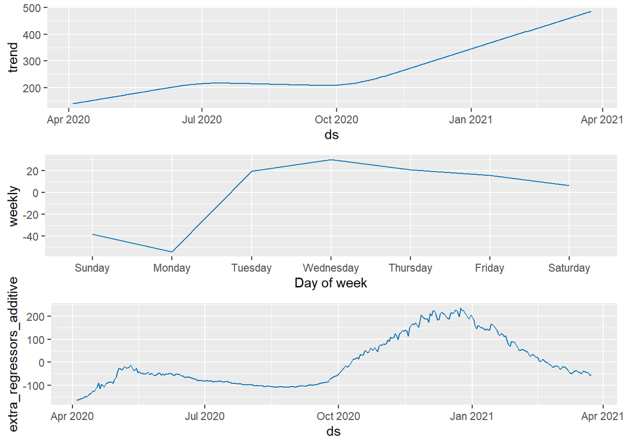

```
## Making 28 forecasts with cutoffs between 2020-06-07 and 2021-03-04
```

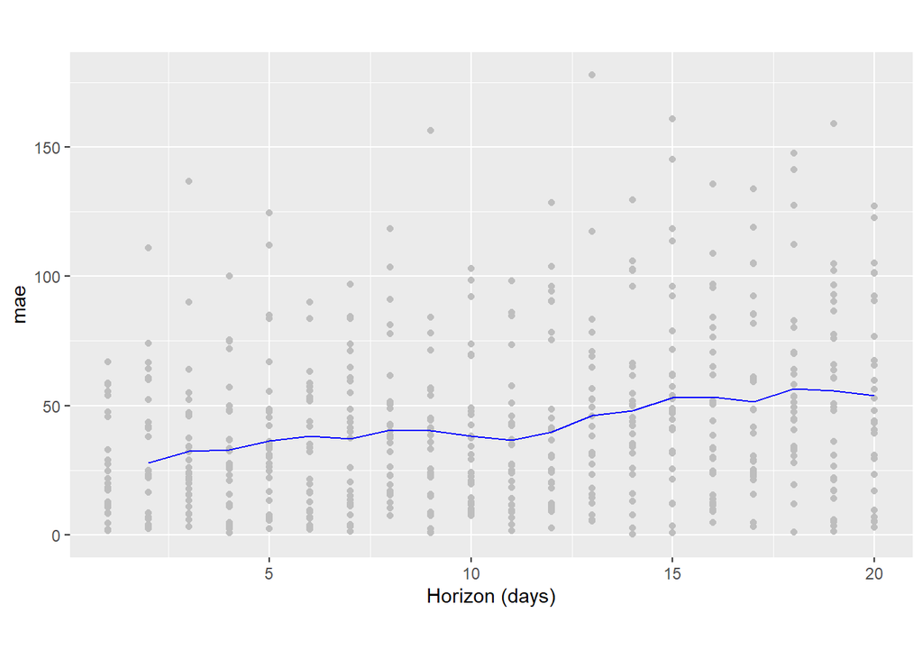

Кросс-валидация показала, что средний модуль ошибки (mae -mean abs. error) добаваление регрессора уменьшило (сравните графики среднего модуля ошибки с регрессором и без регрессора). Хотелось бы учесть влияние числа заболевших для построения прогнозов смертности на будущее, но для этого надо иметь прогноз нашего регрессора `confirmed` в будущем. Это можно сделать многими способами, которые уже были или еще будут в нашем курсе, но мы опять используем пакет `prophet`. Для его построения оценим `prophet` модель для `confirmed` и получим прогноз числа заболевших.

(Skipped Code)

```
## Disabling yearly seasonality. Run prophet with yearly.seasonality=TRUE to override this.
```

```
## Disabling daily seasonality. Run prophet with daily.seasonality=TRUE to override this.
```

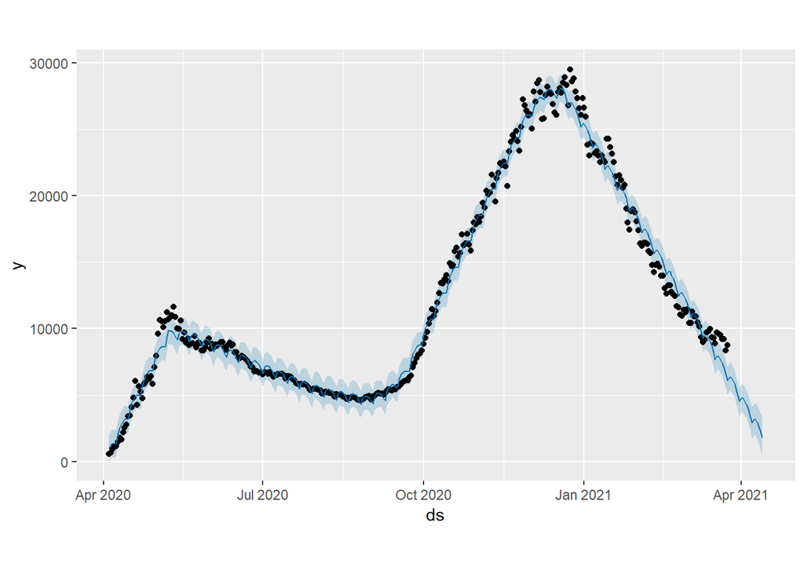

Прогноз для тренда регрессора получен это последние 20 значений в переменной `forecast2$trend`. Добавим их к уже нам известным значениям регрессора `confirmed` и повторим прогнозирование по модели с регрессором. Модель с регрессором уже оценена. Повторная оценка не нужна. Можно сразу приступить к прогнозированию.

(Skipped Code)

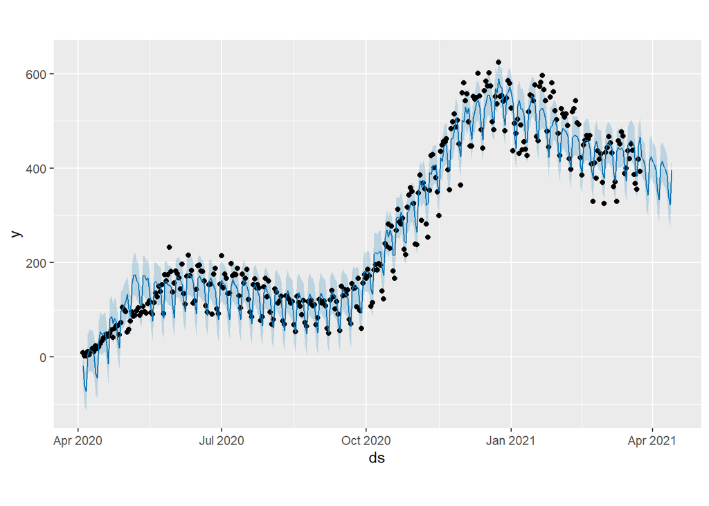

Прогноз с учетом прогноза числа заболевших получен. Здесь есть еще простор для улучшения прогнозов, так как в тренде нет учета сезонной компоненты числа заболевших.

Напоследок просто график следующего процесса, как информация к размышлению.
$$d_t = death_t/confirmed_t*100$$
смертность от COVID-19 в процентах для 6 стран. Если весной прошлого года смертность сильно различалась в странах, к марту 2021 года она почти одинакова.

```r
library(xts)
library(timeSeries)
library(lubridate)
```

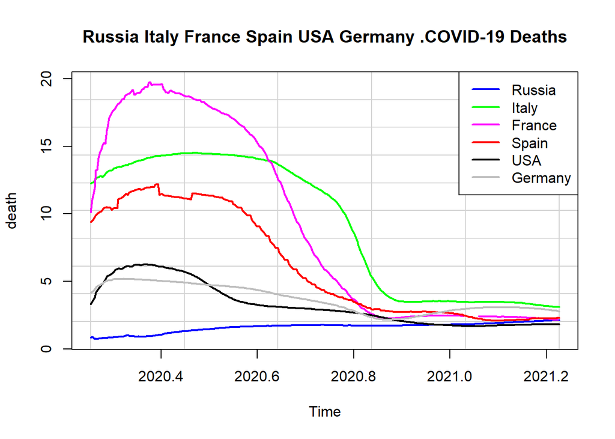

```r
country1 <- "Russia"
country2 <- "Italy"
country3 <- "France"
country4 <- "Spain"
country5 <- "USA"
country6 <- "Germany"
countries <-c(country1,country2,country3,country4,country5,country6)

country1 <- "Russia"
country2 <- "Italy"
country3 <- "France"
country4 <- "Spain"
country5 <- "USA"
country6 <- "Germany"
c1 <-download(country1)
c2 <- download(country2)
c3 <- download(country3)
c4 <- download(country4)
c5 <- download(country5)
c6 <- download(country6)
countries <-c(country1,country2,country3,country4,country5,country6)
cd1 <- c1$deaths/c1$confirmed*100
cd2 <- c2$deaths/c2$confirmed*100
cd3 <- c3$deaths/c3$confirmed*100
cd4 <- c4$deaths/c4$confirmed*100
cd5 <- c5$deaths/c5$confirmed*100
cd6 <- c6$deaths/c6$confirmed*100
minl <-min(c(length(cd1),length(cd2),length(cd3),length(cd4),length(cd5),length(cd6)))
death <- cbind(cd1[1:minl],cd2[1:minl],cd3[1:minl],cd4[1:minl],cd5[1:minl],cd6[1:minl])
death <- ts(death, start = decimal_date(as.Date(c1$date[1],"%Y-%m-%d",origin = "1970-01-01")), freq=365)
plot(death,plot.type = "single",type='l',main = paste(country1,country2,country3,country4,country5,country6, ".COVID-19 Deaths")
,col = c('blue','green','magenta','red','black','gray'),lwd = 2,lty= c(1,1,1,1,1,1),panel.first=grid(nx=NULL,ny = 10,lty=1))
legend("topright",countries,lwd = 2,lty=c(1,1,1,1,1,1),col = c('blue','green','magenta','red','black','gray'))
```

Единственная из 6 стран, где смертность увеличивается это только Россия. Да и картина поведения процесса смертности отличается. Странно это.